# Correlation analysis of ZNF343’s extended motifs

Zheng Zuo

Jun 1, 2022

## Introduction

This Notebook includes the analysis workflow sequal to the previous “Iterative motif analysis of ZNF343”, and is used to show that it is not only feasible, but also necessary to use such an iterative analysis method to extract the full specificity of long, tandem zinc finger proteins (ZFPs). Briefly, I generated the extended motif profiles based on different hexamer anchor sites, including the GAAGCG consensus and all its 18 single variants. Using correlation analysis and hiechical clustering, it is clear that only the GAAGCG consensus and GAAGCn anchors can serve as “good” anchors to produce longer specificity profiles highly similar to published HT-SELEX results, which also lends evidence to our proposed “Dependent recognition”, or “Anchor” model about the recognition of tandem zinc finger proteins. This analysis workflow could be generalzied to analyze other long ZFPs also.

### Parameters used in this analysis workflow

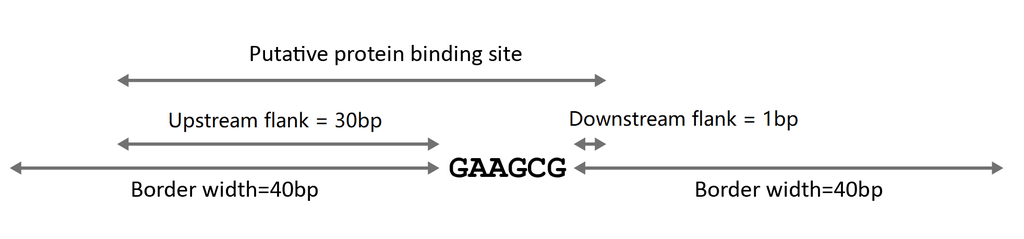

```r
border_width <- 40
upstream_flank <- 30
downstream_flank <- 1

load("data/ZNF343_exo_peaks.RData") # Load processed ChIP-exo data of ZNF343, including exo reads and peaks positions in hg19 genome.
```

## Building recognition models based on different anchor sites

```r
require(furrr)  # Do multi-core parallel computing
plan(multisession)

singleVariants <- tibble(Sequence = TFCookbook::kmer(6)) %>%
  TFCookbook::selectVariants(reference = "GAAGCG", maxMismatches = 1) %>% # Enumerating all single variants of GAAGCG anchor sites
  mutate(Model = furrr::future_map(Sequence, anchorModel)) %>% # Extracting extended specificity info based on each anchor site
  mutate(Anchor_count = purrr::map_int(Model, function(model) length(model$residuals))) # Counting the number of anchors found within ChIP-exo peaks
```

[output not shown]

[output cut: 9 more lines]

### Drawing the extended motif profile of ZNF343 based on consensus GAAGCG anchor site

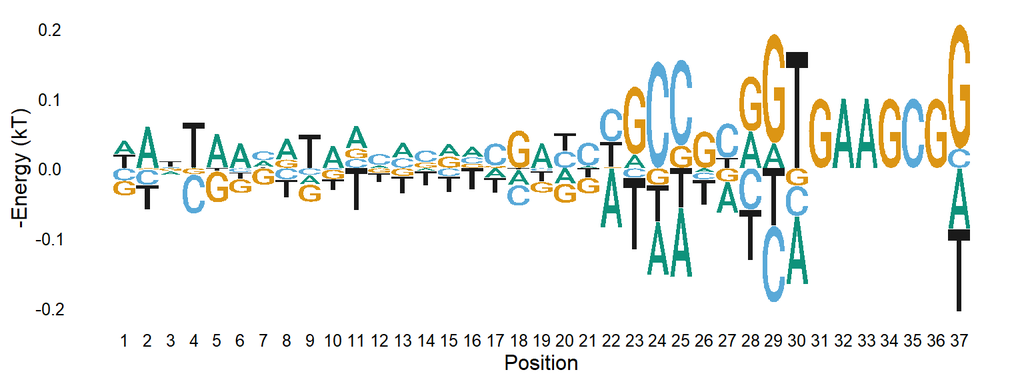

```r
(singleVariants %>%
  filter(Sequence == "GAAGCG"))$Model[[1]] %>%
  getEnergyMatrix() %>%
  TFCookbook::addAnchorMatrix(anchor = "GAAGCG", position=31, height=0.1) %>%
  TFCookbook::plotEnergyLogo()
```

## Importing HT-SELEX result from JASPAR database

```r
ZNF343_SELEX.PFM <- TFBSTools::readJASPARMatrix("data/ZNF343.jaspar")[[1]] %>% TFBSTools::reverseComplement() # Importing PFM from JASPAR database
```

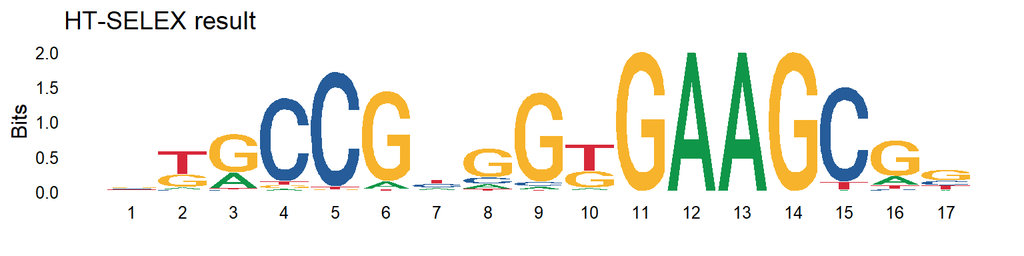

```r
ZNF343_SELEX.PFM@profileMatrix %>%
  ggseqlogo::ggseqlogo() + # Plotting logo of ZNF343 HT-SELEX result
  ggtitle("HT-SELEX result")
```

```r
#ggsave("images/ZNF343_SELEX.svg", width=6, height=3, units="in")
```

```r
as.PEM <- function(PFM){
  num <- dim(PFM)[2]

  ## If some position equals to zero, add pseudocount for calculation.
  PFM[PFM==0] <- 1

  energyMatrix <- matrix(0L, nrow=4, ncol=num, dimnames = list(c("A", "C", "G", "T")))

  for (i in 1:num){
    energyMatrix[,i] <- log(sum(PFM[,i])/PFM[,i] -1)
    energyMatrix[,i] <- energyMatrix[,i]-0.25*sum(energyMatrix[,i])
  }
  return(energyMatrix)
}



(ZNF343_SELEX.Coeffs <-
  (ZNF343_SELEX.PFM@profileMatrix %>%
  as.PEM() %>%
  TFCookbook::as.Coefficients())[c(1:30, 49:51)])
```

```
##         1CG         1CA         1CT         2CG         2CA         2CT
## -0.02613010  1.02014731  0.20752919 -2.44628937 -0.58448875 -3.52609574
##         3CG         3CA         3CT         4CG         4CA         4CT
## -4.38693148 -2.70248119 -0.15582040  5.37602126  5.63145878  5.25259244
##         5CG         5CA         5CT         6CG         6CA         6CT
##  8.06307721  8.17093338  6.95287030 -7.59908295 -2.96235727 -1.32176632
##         7CG         7CA         7CT         8CG         8CA         8CT
##  1.69432953  0.47837912 -0.23131791 -2.46389729  0.33279681  1.07431171
##         9CG         9CA         9CT        10CG        10CA        10CT
## -5.34682007  0.10779731  1.35736843 -3.62811410 -1.49268648 -4.49209050
##        17CG        17CA        17CT
## -1.29675228  1.48992095  0.08504096
```

## Ploting extended motif for each anchor site based on the ChIP-exo reads in flanking regions

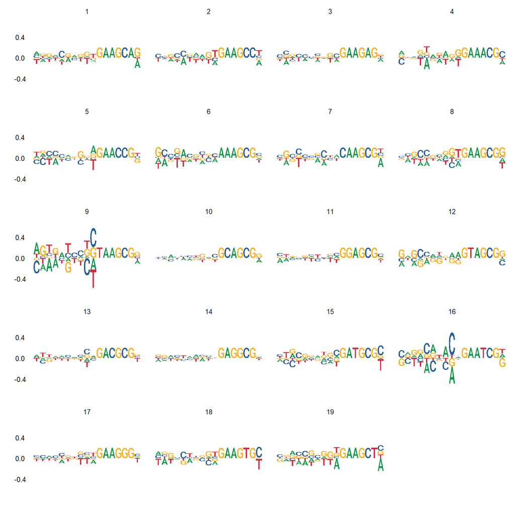

```r
logo_list <- purrr::map2(
  singleVariants$Sequence,
  singleVariants$Model,
  function(anchor, model) {
    -(TFCookbook::getEnergyMatrix(model) %>%
      TFCookbook::addAnchorMatrix(anchor = anchor, position = 31, height = 0.2))[,21:37]
  }
)

(logos <- ggplot() +
  ggseqlogo::geom_logo(logo_list, method="custom", seq_type = "dna")  +
  ggseqlogo::theme_logo() +
  facet_wrap(~seq_group, ncol=4, scales='free_x') +
  ylim(-0.7, 0.7) +
 # scale_x_continuous(breaks = seq(1,17,2), label = seq(1,17,2)) +
  theme(axis.text.x = element_blank())
    )
```

```r
#ggsave("images/ZNF343_logos.eps", plot=logos, width=10, height=10, units="in")
```

## Comparing extended motifs of all single variants and published HT-SELEX result

### Building Heatmap and Hiechical clustering based on the correlation coefficients between pairs of extended motifs

```r
Heatmap_data <- sapply(singleVariants$Model, function(x) x$coefficients[c(62:91,110:112)]) %>%
#Heatmap_data <- sapply(singleVariants$Model, function(x) x$coefficients[c(62:91)]) %>%
  na.omit() %>%
  as.data.frame()

colnames(Heatmap_data) <- singleVariants$Sequence

Heatmap_data$'HT-SELEX' <- ZNF343_SELEX.Coeffs
singleVariants$Sequence
```

```
##  [1] "GAAGCA" "GAAGCC" "GAAGAG" "GAAACG" "GAACCG" "AAAGCG" "CAAGCG" "GAAGCG"
##  [9] "TAAGCG" "GCAGCG" "GGAGCG" "GTAGCG" "GACGCG" "GAGGCG" "GATGCG" "GAATCG"
## [17] "GAAGGG" "GAAGTG" "GAAGCT"
```

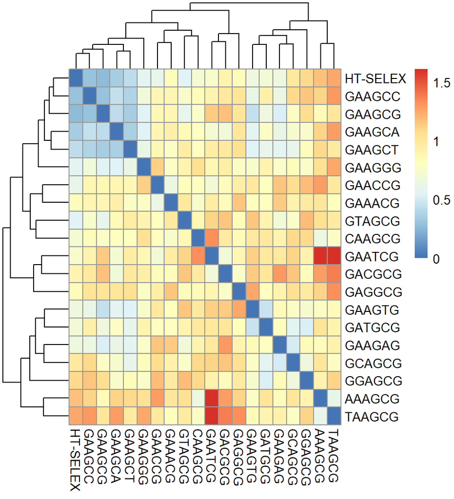

```r
Heatmap.matrix = 1-cor(Heatmap_data)
# Modify ordering of the clusters using clustering callback option
callback = function(hc, mat){
    weights = -1*c(6, 6, 5, 4, 16, 1, 1, 50, 1, 2, 2, 2, 3, 3, 3, 4, 5, 5, 6, 100)
    sv = svd(t(mat))$v[,1]
    dend = reorder(as.dendrogram(hc), wts = weights)
    as.hclust(dend)
}


Heatmap <- pheatmap::pheatmap(Heatmap.matrix, clustering_callback = callback, fontfamliy = "mono")
```

```r
#ggsave("images/Heatmap_ZNF343.eps", plot=Heatmap, height = 5.5, width = 5)
```

### Displaying the total number anchors sites found within the ChIP-exo peaks

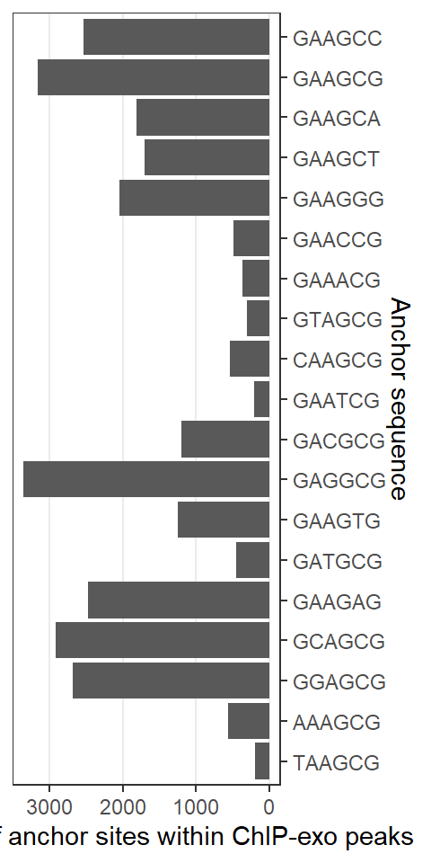

```r
order = c("HT-SELEX", "GAAGCC", "GAAGCG", "GAAGCA", "GAAGCT",
          "GAAGGG",   "GAACCG", "GAAACG", "GTAGCG", "CAAGCG",
          "GAATCG",   "GACGCG", "GAGGCG", "GAAGTG", "GATGCG",
          "GAAGAG",   "GCAGCG", "GGAGCG", "AAAGCG", "TAAGCG")

(singleVariants %>%
  mutate(Sequence = factor(Sequence, levels = order),
         Anchor_count = as.integer(Anchor_count)) %>%
  ggplot(aes(y=Sequence, x=Anchor_count)) +
  geom_bar(stat="identity",orientation = "y") +
  xlab("Number of anchor sites within ChIP-exo peaks")  + scale_x_reverse(expand = expansion(mult = 0, add = 150)) +
  ylab("Anchor sequence") + scale_y_discrete(limits=rev, position = "right") + theme_bw() +
  theme(panel.grid.minor = element_blank(),
        panel.grid.major.y = element_blank())-> plot.Anchor.count)
```

```r
#cowplot::plot_grid(plot.Anchor.count,
 #                  ggplotify::as.ggplot(Heatmap), ncol = 2,
  #                 rel_widths = c(1, 2),
   #                align = "h", axis = "b")

ggsave("images/ZNF343.Anchors.eps", plot = plot.Anchor.count, height = 5, width = 2.5)
```

## Summary of results

[figure not shown]